# Short Report 1

Jake VanCampen

16-Jan-2018

The following code generates a file containing coin flip trials for 100 coins. The distribution of probabilities of getting a head for each coin, over all coins, roughly follows a beta-binomial distribution.

```r
set.seed(32)
ncoins <- 100
true_alpha <- 3
true_beta <- 2
probs <- rbeta(ncoins, shape1=true_alpha, shape2=true_beta)
nflips <- rnbinom(ncoins, size=5, prob=0.4)
nheads <- rbinom(ncoins, size=nflips, prob=probs)
outfile <- file("coin_flips.txt", open="w")
outliers <- 32
outlier_num <- c(max(nflips)-1, 1)
for (k in 1:ncoins) {
    if (k %in% outliers) {
        cat(paste0(paste(sample(c(rep("H",outlier_num[1]), rep("T",outlier_num[2]))), collapse=''), "\n"), file=outfile)
    } else {
        cat(paste0(paste(sample(c(rep("H",nheads[k]), rep("T",nflips[k]-nheads[k]))), collapse=''), "\n"), file=outfile)
    }
}
close(outfile)
```

The files output appears as follows:

```r
coin_data <- read.table('coin_flips.txt')
head(coin_data)
```

```
##          V1
## 1    HHTHHH
## 2  THTHTTTT
## 3  HHHHTHHH
## 4    HHHHTH
## 5 TTHTTHHTH
## 6 TTTTHHTHT
```

Each row of the file represents a number of trials for a specific coin. The number of characters is the number of flips, and the number of H’s is the number of heads for those trials.

Each coin has a probability of heads, $\theta$, that across all coins should follow a $\beta$ distribution. The shape of the $\beta$, the resulting parameters $\alpha$ and $\beta$ can be estimated using maximum likelihood.

We need to obtain the list of the proportion of heads flipped per coin. First, the total number of characters can be calculated.

```r
# all characters
total_chars <- nchar(as.character(coin_data$V1))
```

To obtain the number of heads for the trials, the H’s are replaced with nothing and the resulting number of characters is subtracted from the original. Then the probability of getting a head in those trials is calculated.

```r
# remove heads
minus_heads <- nchar(gsub('H', '',as.character(coin_data$V1)))

# number heads per coin
num_heads <- total_chars - minus_heads

# calculate heads probability
prob_heads <- (total_chars - minus_heads)/total_chars
```

Let’s see how the proportions are distributed…

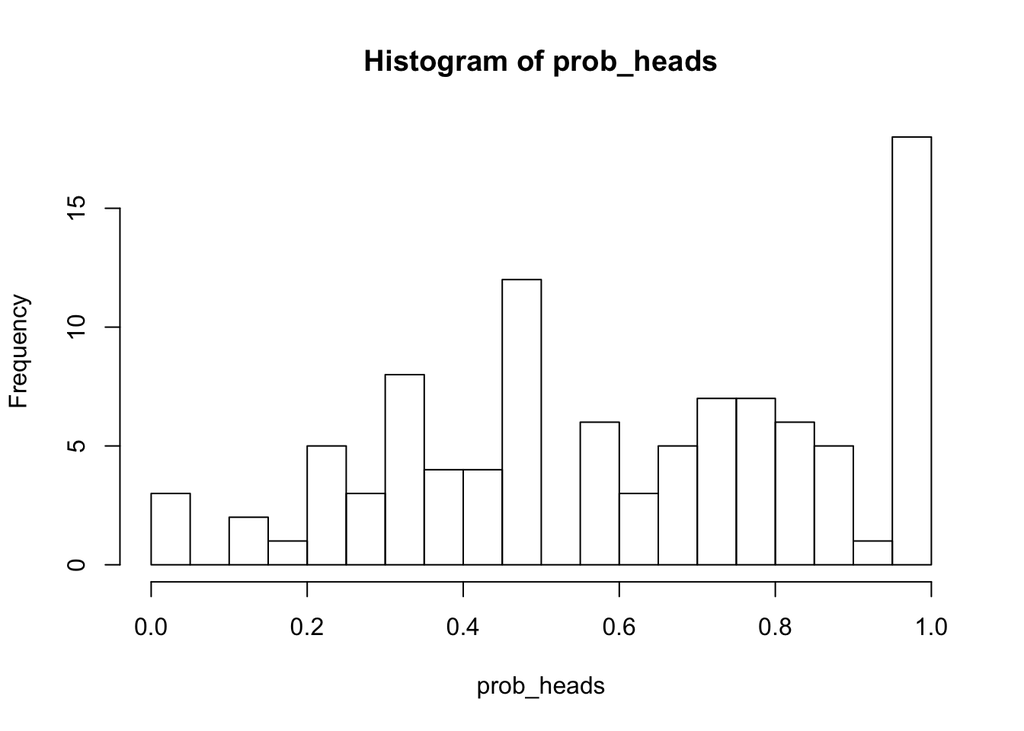

```r
hist(prob_heads, breaks = 30)
```

There are not many trials for each coin, so there is a lack of data to make this distribution very characteristic.

To estimate the distribution of probabilities for each coin more clearly, given the konwn data, maximum likelihood can be used to estimate the parameters of the beta-binomial distribution: alpha and beta.

given the probability mass function of the beta-binomial distribution:

$$P(X|Z = z) = \binom{n}{z} \frac{B(k + \alpha, n-z + \beta)}{B(\alpha, \beta)}$$

The log likelihood of this function can be optimized to find the parameter values alpha and beta as follows:

```r
# define n and z
n <- total_chars
z <- num_heads

# create log likelihood funciton to optimize
beta_binom_loglike <- function(params, x) {
  sum(-(lchoose(n,z) +
  lbeta(params[1]+z,params[2]+n-z) -
  lbeta(params[1], params[2])))
}

#optimize funciton using the proportion of heads for each coin as input
out <- optim(par = c(1,1), fn=beta_binom_loglike, x=prob_heads)

# parameter estimates
alpha_estimate <- out$par[1]
beta_estimate <- out$par[2]
```

The maximum likelihood estimate of the parameters for the underlying beta-distribution are alpha = 2.5679763 and beta = 1.5317949.

How well do the proportions compare to a $\beta$ distribution with the simulated parameter values?

The beta distribution characterized by the estimated alpha and beta parameters is scaled by a factor of 10 for comparison to the histogram of heads proportions (z/n) for each coin.

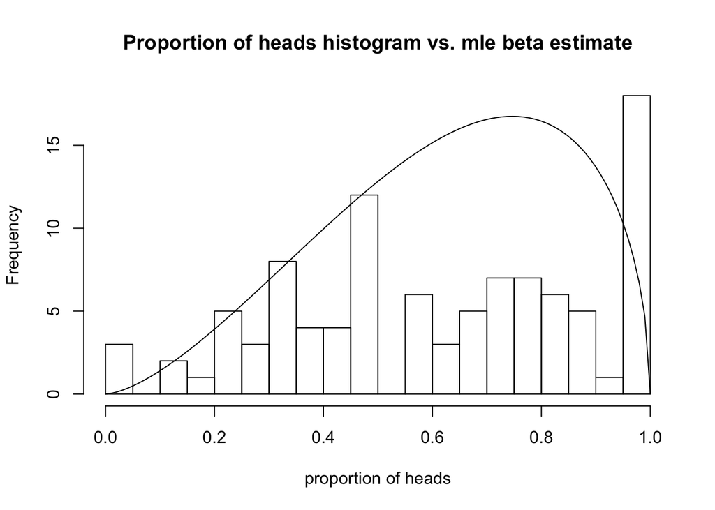

```r
x = seq(0, 1, length.out = 100)
y = 10*dbeta(x,alpha_estimate,beta_estimate)

hist(prob_heads, breaks = 15, main = 'Proportion of heads histogram vs. mle beta estimate', xlab = 'proportion of heads')
points(x,y, 'l')
```

If you squint hard enough, you could convince yourself that the histogram and the line modeling the maximum likelihood parameter estimate are similar distributions. Given the true_alpha = 3, and true_beta = 2. The MLE estimate is clsose (2.5679763, 1.5317949) respectively.